# Data Preparation for Graph Convolutional Neural Networks

## Load Modules

```python
import sys
sys.path.insert(1, '../..')

import matplotlib as mpl
mpl.rcParams.update(mpl.rcParamsDefault)
mpl.rcParams.update({"ytick.color" : "black",
        "xtick.color" : "black",
        "ytick.color" : "black",
        "xtick.labelsize" : "large",
        "ytick.labelsize" : "large",
        "axes.labelcolor" : "black",
        "axes.edgecolor" : "black",
        "text.usetex" : True,
        "font.family" : "serif",
        "font.serif" : ["Computer Modern Serif"],
        "font.weight" : "bold"})

# mpl.use("qt5agg")
import matplotlib.pyplot as plt
from matplotlib.lines import Line2D
from matplotlib.patches import Rectangle


import numpy as np
np.set_printoptions(precision=2, linewidth=1000, edgeitems=8, suppress=True)

import pandas as pd
# pd.set_option('display.width', 10000)
pd.set_option('display.max_colwidth', 50)  # or 199
import warnings
warnings.filterwarnings("default")


import geopandas as gpd
import networkx as nx
from sqlalchemy import create_engine
from random import randint, random

import preparation_package as pp

from shapely.geometry import LineString, MultiLineString

import multiprocessing as mp
number_of_cores = 5

from itertools import chain
from tqdm.notebook import tqdm

import pickle

import math
import random
import os
```

## Import from Database

```python
subset = "ch"

if subset == "ch":
    db_connection_url = "postgresql://nicibe@localhost:5432/deepgen_roads"
    con = create_engine(db_connection_url)
    sql = "SELECT * FROM processed.krm25_selected_grid"
    krm25 = gpd.GeoDataFrame.from_postgis(sql, con, geom_col='geometry')
    sql = "SELECT * FROM processed.dkm100_grid"
    dkm100 = gpd.GeoDataFrame.from_postgis(sql, con, geom_col='geometry')

else:
    db_connection_url = "postgresql://nicibe@localhost:5432/deepgen_roads"
    con = create_engine(db_connection_url)
    sql = f"SELECT * FROM {subset}.krm25_{subset}_select_grid"
    krm25 = gpd.GeoDataFrame.from_postgis(sql, con, geom_col='geometry')
    sql = f"SELECT * FROM {subset}.dkm100_strasse_{subset}"
    dkm100 = gpd.GeoDataFrame.from_postgis(sql, con, geom_col='geometry')
```

```python
assert len(krm25) == len(dkm100)
print(f"{len(krm25)=}")
```

```
len(krm25)=643523
```

## Multipart to singlepart

**Right now, all MultiLineString geometries are omitted**

There are dkm100_uuid's in the join table (dkm100_strassen_fv) that are not present in dkm100_strassen. Thus, they are joined in the sql script but there is no geometry present. For this reason in the following code block, a list of the dkm100_uuid's that have a nonetype geometry are saved and deleted. The saved dkm100_uuid's can then be used to delete the roads in the krm25 dataset

```python
nonetype_dkm100_uuids = []
for _, road in dkm100.iterrows():
    if isinstance(road['geometry'], type(None)):
        nonetype_dkm100_uuids.append(road.uuid_for_debugging)

multilinestring_dkm100_uuids = []
for _, road in krm25.iterrows():
    if isinstance(road['geometry'], MultiLineString):
        multilinestring_dkm100_uuids.append(road.dkm100_uuid)

dkm100 = dkm100[~dkm100['uuid_for_debugging'].isin(nonetype_dkm100_uuids)]
dkm100 = dkm100[~dkm100['uuid'].isin(multilinestring_dkm100_uuids)]
krm25 = krm25[~krm25['dkm100_uuid'].isin(nonetype_dkm100_uuids)]
krm25 = krm25[~krm25['dkm100_uuid'].isin(multilinestring_dkm100_uuids)]


dkm100 = pp.multipart_to_singlepart(dkm100)
# krm25 = pp.multipart_to_singlepart(krm25)

assert len(krm25) == len(dkm100)
print(f"{len(krm25)=}")
```

```
len(krm25)=635131
```

## Create subgraphs

Check the distribution of road lenghts

```python
length_counts = [0 for _ in range(400)]


for road_i, road in krm25.iterrows():
    subgraph = krm25.loc[[road_i]]
    try:
        length_counts[len(list(subgraph.iloc[0].geometry.coords))] += 1

    except IndexError:
        length_counts[-1] += 1


length_counts = np.array(length_counts)
```

```
1567
13366
0
```

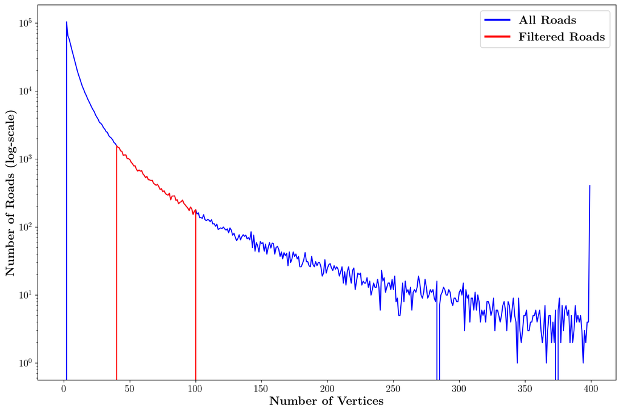

```python
print(length_counts[40])
print(np.sum(length_counts[60:101]))
print(np.min(length_counts))

filter = length_counts * 1
filter[:40] = 0
filter[101:] = 0

plt.figure(figsize=(15, 10), dpi=300)
plt.plot(list(range(400)), length_counts[:], color="b")
plt.plot(list(range(400)), filter[:], color="r")
plt.yscale("log")
plt.ylabel(r"\textbf{Number of Roads (log-scale)}", fontsize="xx-large")
plt.xlabel(r"\textbf{Number of Vertices}", fontsize="xx-large")

#legend
handles = [Line2D([0], [0], color=c, lw=3) for c in ['b', 'r']]
labels=[r"\textbf{All Roads}", r"\textbf{Filtered Roads}"]
plt.legend(handles, labels, bbox_to_anchor=(1, 1), fontsize="xx-large")
plt.show()
```

Create krm25 subgraphs

```python
krm25.reset_index(inplace=True)
krm25_index = krm25.sindex

only_focal_road = False

orig_subgraphs = []
gen_subgraphs_indices = []

global_graph_idx = 0
for road_i, road in krm25.iterrows():

    # if only_focal_road is True, only one road per graph is taken
    if only_focal_road:
        subgraph = krm25.loc[[road_i]]
        length = len(subgraph.iloc[0].geometry.coords)
    else:
        neighbours = list(krm25_index.query(
            geometry=road['geometry'],
            predicate='touches'
        ))
        subgraph = krm25.loc[[road_i] + neighbours]

    # if 60 <= length <= 100:
    if True:
        subgraph['road_id'] = global_graph_idx

        orig_subgraphs.append(subgraph)

        # save dkm100_uuid's to create the same subgraphs for dkm100
        gen_subgraphs_indices.append(subgraph['dkm100_uuid'])

        global_graph_idx += 1

    if road_i % 10000 == 0:
        print(f"Road {road_i} of {len(krm25)} ({round(100 * road_i/len(krm25), 1)} %)", end="\r")


subgraphs_it = iter(orig_subgraphs)
print()
print(f'{len(orig_subgraphs)=}')
```

```
Road 630000 of 635131 (99.2 %)
len(orig_subgraphs)=635131
```

Create dkm100 subgraphs

```python
gen_subgraphs = []
with mp.Pool(number_of_cores) as pool:
    gen_subgraphs = pool.starmap(
        pp.get_dkm100_subgraphs_from_indcs,
        tqdm(
            [(subgraph, dkm100) for subgraph in gen_subgraphs_indices],
            total=len(gen_subgraphs_indices))
    )
```

Save intermediary product

```python
# with open("../../data.nosync/intermediary_products/allCH_with-neighbours-krm25.pickle", "wb") as file:
#     pickle.dump(orig_subgraphs, file)

# with open("../../data.nosync/intermediary_products/allCH_with-neighbours-dkm100.pickle", "wb") as file:
#     pickle.dump(gen_subgraphs, file)
```

## Filter Roads according to distance on ends

```python
with open("../../data.nosync/intermediary_products/allCH_60to100_krm25.pickle", "rb") as file:
    orig_subgraphs = pickle.load(file)

with open("../../data.nosync/intermediary_products/allCH_60to100_dkm100.pickle", "rb") as file:
    gen_subgraphs = pickle.load(file)

num_subgraphs = len(orig_subgraphs)
num_subgraphs

with open("../../data.nosync/intermediary_products/allCH_with-neighbours-krm25.pickle", "rb") as file:
    krm25_neighbours = pickle.load(file)

with open("../../data.nosync/intermediary_products/allCH_with-neighbours-dkm100.pickle", "rb") as file:
    dkm100_neighbours = pickle.load(file)
```

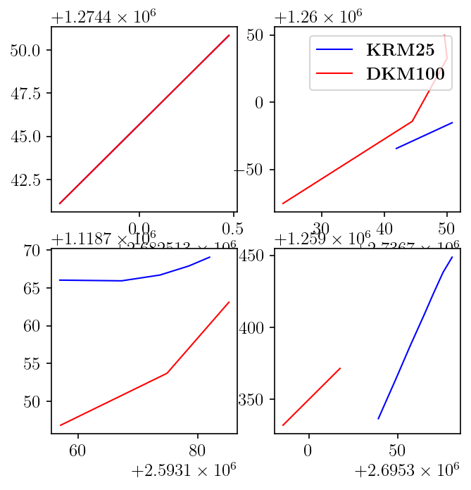

```python
from matplotlib.lines import Line2D

fig, axes = plt.subplots(nrows=2, ncols=2, figsize=(5, 5), dpi=150)
for i in range(2):
    for j in range(2):
        while True:
            random_idx = randint(0, len(krm25_neighbours))
            rand_road = krm25.iloc[[random_idx]]
            try:
                if len(rand_road.iloc[0].geometry.coords) < 10:
                    break
            except NotImplementedError:
                pass

        lw = 1
        krm25_coords = np.array(rand_road.explode(index_parts=True).iloc[0].geometry.coords)
        dkm100_coords = np.array(dkm100[dkm100['uuid'] == rand_road['dkm100_uuid'].values[0]].explode(index_parts=True).iloc[0].geometry.coords)
        both = np.vstack((krm25_coords, dkm100_coords))

        axes[i, j].plot(krm25_coords[:, 0], krm25_coords[:, 1], color='blue', lw=lw)
        axes[i, j].plot(dkm100_coords[:, 0], dkm100_coords[:, 1], color='red', lw=lw)

        #legend
        handles = [Line2D([0], [0], color=c, lw=lw) for c in ['b', 'r']]
        labels=[r"\textbf{KRM25}", r"\textbf{DKM100}"]
        legend = plt.legend(handles, labels, bbox_to_anchor=(1, 2.2), fontsize="large")

        fig.legend = legend
        # print(random_idx)
```

Compute distances between start- and end-vertices

```python
distances_start = []
distances_end = []

for i in range(num_subgraphs):
    orig_coords = np.array(orig_subgraphs[i].iloc[0].geometry.coords)
    gen_coords = np.array(gen_subgraphs[i].iloc[0].geometry.coords)

    diff_start = np.abs(orig_coords[0, :] - gen_coords[0, :])
    dist_start = np.sqrt(diff_start[0]**2 + diff_start[1]**2)
    distances_start.append(dist_start)

    diff_end = np.abs(orig_coords[-1, :] - gen_coords[-1, :])
    dist_end = np.sqrt(diff_end[0]**2 + diff_end[1]**2)
    distances_end.append(dist_end)

max_distance = [max([startdist, enddist]) for startdist, enddist in zip(distances_start, distances_end)]
print(f'{max(max_distance) = }')
```

```
max(max_distance) = 2366.943230441112
```

- Visualize distribution of distances
- Get filter distance from quantiles -> Probably 0.8

```
Filter Cut Distance (quantile=0.8): 337.7 meters (with randomness)
```

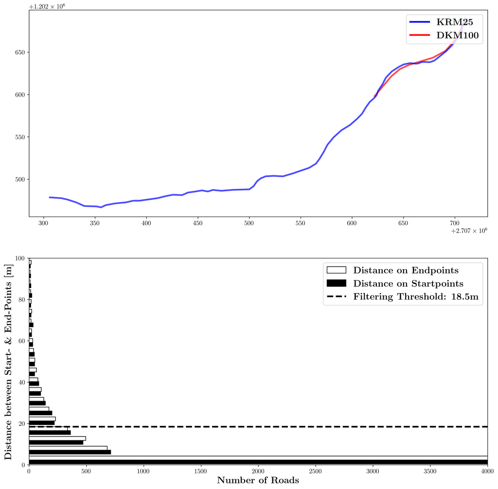

```python
def get_idx_from_quantile(quantile, values, num_samples, randomness = True):
    rank = int(num_samples * quantile) + 2500 + (randomness * random.randint(-10, 10))
    return values.index(sorted(values)[rank])

quantile = 0.8
filtercut_idx = get_idx_from_quantile(quantile, max_distance, num_subgraphs, randomness=True)
print(f"Filter Cut Distance (quantile={quantile}): {round(max_distance[filtercut_idx], 1)} meters (with randomness)")


_, axs = plt.subplots(ncols=1, nrows=2, figsize=(15, 15), dpi=300)
axs[0].plot(np.array(gen_subgraphs[filtercut_idx].iloc[0].geometry.coords)[:, 0], np.array(gen_subgraphs[filtercut_idx].iloc[0].geometry.coords)[:, 1], color='red',
    linewidth=3,
    alpha=0.7)
axs[0].plot(
    np.array(orig_subgraphs[filtercut_idx].iloc[0].geometry.coords)[:, 0],
    np.array(orig_subgraphs[filtercut_idx].iloc[0].geometry.coords)[:, 1],
    color='blue',
    linewidth=3,
    alpha=0.7)

#legend
handles = [Line2D([0], [0], color=c, lw=3) for c in ['b', 'r']]
labels=[r"\textbf{KRM25}", r"\textbf{DKM100}"]
axs[0].legend(handles, labels, loc="upper right", fontsize="xx-large")

hist = axs[1].hist(
    [distances_start, distances_end],
    color=["black", "white"],
    edgecolor="black",
    bins=500, # range(0, math.ceil(max(distances_start+distances_end)), 10),
    orientation="horizontal"
)
axs[1].hlines(
    18.5, # max_distance[filtercut_idx],
    0, 12000, color="black", linestyles="dashed", linewidth=3)
axs[1].set_ylim((0, 100))
axs[1].set_xlim((0, 4000))
axs[1].set_xlabel(
    r"\textbf{Number of Roads}",
    fontsize="xx-large")

axs[1].set_ylabel(
    r"\textbf{Distance between Start- \& End-Points [m]}",
    fontsize="xx-large")
#legend
handles = [Rectangle((0, 0), 4, 2, facecolor=c, edgecolor="black") for c in ['white', 'black']]
handles += [Line2D([0], [0], linewidth=3, color="black", linestyle="dashed")]
labels=[r"\textbf{Distance on Endpoints}", r"\textbf{Distance on Startpoints}", r"\textbf{Filtering Threshold: 18.5m}"]
axs[1].legend(handles, labels, loc="upper right", fontsize="xx-large")

plt.show()
```

Filtering

```python
filtercut_idx = get_idx_from_quantile(0.80, max_distance, num_subgraphs, randomness=False)
print(f"Filter Cut Distance (quantile={quantile}): {round(max_distance[filtercut_idx], 1)} meters")
count = 0

filtered_orig_subgraphs = []
filtered_gen_subgraphs = []
for i in range(num_subgraphs):
    if max_distance[i] <= 18.5:
        filtered_orig_subgraphs.append(orig_subgraphs[i])
        filtered_gen_subgraphs.append(gen_subgraphs[i])
        count += 1
count
```

```
Filter Cut Distance (quantile=0.8): 334.6 meters
```

```
10705
```

```python
orig_subgraphs = filtered_orig_subgraphs
gen_subgraphs = filtered_gen_subgraphs
num_subgraphs = len(filtered_orig_subgraphs)
```

## Compute relative coords

Load Intermediary Product

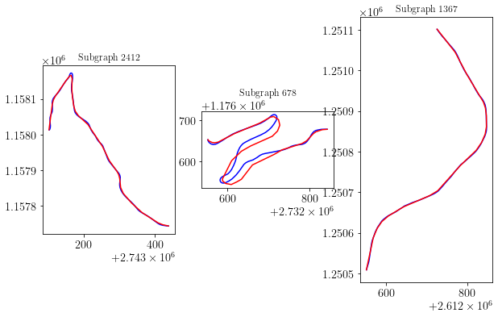

```python
import warnings
warnings.filterwarnings("ignore", category=DeprecationWarning)

_, ax = plt.subplots(nrows=1, ncols=3, figsize=(10, 40))
for i in range(3):
    while True:
        rand_i = randint(0, len(orig_subgraphs))
        if len(list(orig_subgraphs[rand_i].iloc[0].geometry.coords)) > 30:
            orig_subgraphs[rand_i].plot(ax=ax[i], color="blue")
            gen_subgraphs[rand_i].plot(ax=ax[i], color="red")
            ax[i].set_title(f"Subgraph {rand_i}")
            break
```

Get relative coords of original graphs

```python
num_subgraphs = len(orig_subgraphs)

# print("Computing relative coordinates")
with mp.Pool(number_of_cores) as pool:
    orig_subgraphs = pool.map(
        pp.get_relative_coords,
        tqdm(orig_subgraphs, total=num_subgraphs))
```

Get relative coords of generalized graphs

```python
with mp.Pool(number_of_cores) as pool:
    gen_subgraphs = pool.starmap(
        pp.get_relative_coords,
        tqdm(
            [
                (gen_subgraphs[i],
                [orig_subgraphs[i]['origin'].values[0], orig_subgraphs[i]['reference_angle'].values[0]])
            for i in range(num_subgraphs)]))
```

```python
for i in range(num_subgraphs):
    orig_subgraphs[i]['graph_id'] = i
    gen_subgraphs[i]['graph_id'] = i
```

```python
orig_subgraphs[0]
```

|  | index | krm25_uuid | dkm100_uuid | befahrbarkeit | belagsart | objektart | geometry | grid_id | grid_left | grid_bottom | road_id | polar_coordinates | local_cartesian_coordinates | origin | reference_angle | graph_id |
| --- | --- | --- | --- | --- | --- | --- | --- | --- | --- | --- | --- | --- | --- | --- | --- | --- |
| 8 | 8 | {00423317-D322-4BA7-8CBE-986811F60807} | {A310E389-DCF3-43BA-8A20-7B9A01CC12DE} | -99 | 200 | 1700 | LINESTRING (2786018.491 1144710.851, 2786018.8... | 706 | 2.785437e+06 | 1.136226e+06 | 0 | [[102.99642826439138, 0.0], [14.57115487404267... | [[0.0, 0.0], [-0.36625000089406967, 13.3225000... | [2786018.491250001, 1144710.8512500003] | -102.996428 | 0 |

```python
#source: http://stackoverflow.com/questions/20023209/python-function-for-rotating-2d-objects

def rotatePolygon(polygon,theta):
    """Rotates the given polygon which consists of corners represented as (x,y),
    around the ORIGIN, clock-wise, theta degrees"""
    theta = math.radians(theta)
    rotatedPolygon = []
    for corner in polygon :
        rotatedPolygon.append(( corner[0]*math.cos(theta)-corner[1]*math.sin(theta) , corner[0]*math.sin(theta)+corner[1]*math.cos(theta)) )
    return rotatedPolygon
```

```python
for orig_road, gen_road in zip(orig_subgraphs, gen_subgraphs):

    orig_coords = list(orig_road.iloc[0].local_cartesian_coordinates)
    orig_coords_np = np.array(orig_coords)

    location_vector = orig_coords_np[0, :]
    direction_vector = orig_coords_np[-1, :] - orig_coords_np[0, :]
    graph_angle = math.degrees(math.atan2(
        direction_vector[1], direction_vector[0]))

    gen_coords = list(gen_road.iloc[0].local_cartesian_coordinates)
    gen_coords_np = np.array(gen_coords)

    orig_rotated_coords_np = np.array(rotatePolygon(orig_coords, 90 - graph_angle))
    gen_rotated_coords_np = np.array(rotatePolygon(gen_coords, 90 - graph_angle))

    orig_road['rotated_local_cartesian_coordinates'] = [orig_rotated_coords_np]
    orig_road['rotation_angle'] = 90 - graph_angle
    gen_road['rotated_local_cartesian_coordinates'] = [gen_rotated_coords_np]
    gen_road['rotation_angle'] = 90 - graph_angle
```

## Flip around x-Axis if largest deviation isn't positive

```python
for i, (orig_road, gen_road) in enumerate(zip(orig_subgraphs, gen_subgraphs)):

    orig_coords = orig_road.iloc[0].rotated_local_cartesian_coordinates
    gen_coords = gen_road.iloc[0].rotated_local_cartesian_coordinates

    max_x = orig_coords[:, 0].max()
    min_x = orig_coords[:, 0].min()

    flipped = False
    if abs(max_x) < abs(min_x):
        orig_coords[:, 0] *= -1
        gen_coords[:, 0] *= -1
        flipped = True

    orig_road['flipped_local_cartesian_coordinates'] = [orig_coords]
    orig_road['flipped_bool'] = flipped
    gen_road['flipped_local_cartesian_coordinates'] = [gen_coords]
    gen_road['flipped_bool'] = flipped
```

```python
gen_subgraphs[0]
```

|  | uuid | geometry | uuid_for_debugging | dkm100_uuid | grid_id | grid_left | grid_bottom | polar_coordinates | local_cartesian_coordinates | origin | reference_angle | graph_id | rotated_local_cartesian_coordinates | rotation_angle | flipped_local_cartesian_coordinates | flipped_bool |
| --- | --- | --- | --- | --- | --- | --- | --- | --- | --- | --- | --- | --- | --- | --- | --- | --- |
| 164931 | {A310E389-DCF3-43BA-8A20-7B9A01CC12DE} | LINESTRING (2786018.566 1144710.656, 2786017.2... | {A310E389-DCF3-43BA-8A20-7B9A01CC12DE} | {A310E389-DCF3-43BA-8A20-7B9A01CC12DE} | 706 | 2.785437e+06 | 1.136226e+06 | [[34.03393906976844, 0.2089258241684602], [9.2... | [[-0.07499999925494194, 0.19500000029802322], ... | [2786018.491250001, 1144710.8512500003] | -102.996428 | 0 | [[-0.11693241684527919, 0.1731381237486193], [... | 12.996428 | [[-0.11693241684527919, 0.1731381237486193], [... | False |

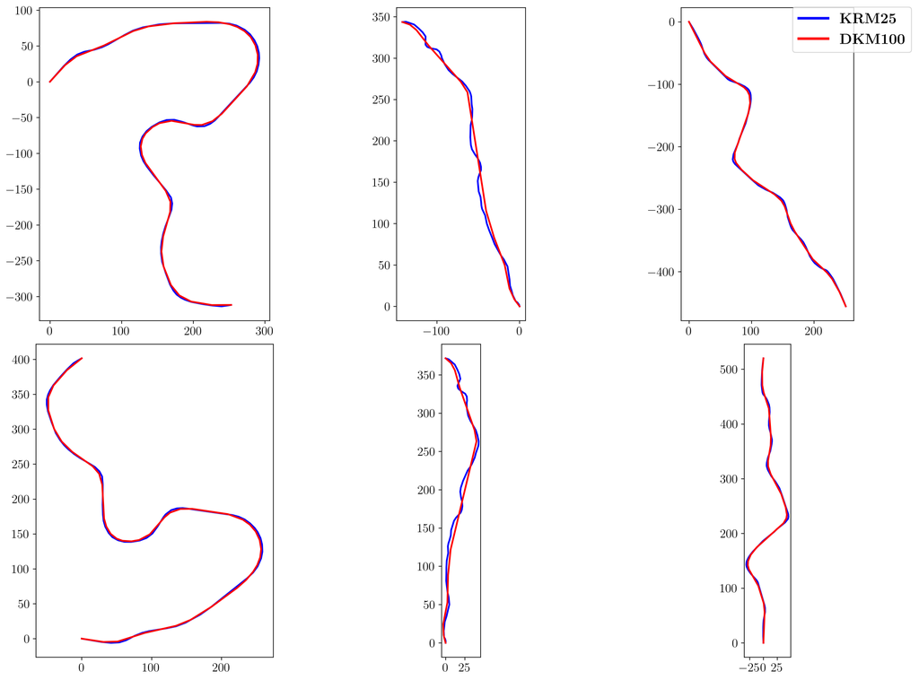

```python
fig, ax = plt.subplots(nrows=2, ncols=3, figsize=(15, 11), dpi=300, layout="constrained")

for i in range(3):
    random_idx = randint(0, len(orig_subgraphs))
    orig = orig_subgraphs[random_idx].iloc[0]['local_cartesian_coordinates']
    gen = gen_subgraphs[random_idx].iloc[0]['local_cartesian_coordinates']
    orig_transformed = orig_subgraphs[random_idx].iloc[0]['flipped_local_cartesian_coordinates']
    gen_transformed = gen_subgraphs[random_idx].iloc[0]['flipped_local_cartesian_coordinates']

    ax[0, i].plot(orig[:, 0], orig[:, 1], color='blue', lw=2)
    ax[0, i].plot(gen[:, 0], gen[:, 1], color='red', lw=2)
    ax[0, i].set_aspect("equal")

    ax[1, i].plot(orig_transformed[:, 0], orig_transformed[:, 1], color='blue', lw=2)
    ax[1, i].plot(gen_transformed[:, 0], gen_transformed[:, 1], color='red', lw=2)
    ax[1, i].set_aspect("equal")

#legend
handles = [Line2D([0], [0], color=c, lw=3) for c in ['b', 'r']]
labels=[r"\textbf{KRM25}", r"\textbf{DKM100}"]
fig.legend(handles, labels, loc="upper right", fontsize="xx-large")
```

## Compute Geometric Attributes

### Angles at Vertices

```python
with mp.Pool(number_of_cores) as pool:
    orig_subgraphs = pool.map(
        pp.get_angle_at_vertices,
        tqdm(orig_subgraphs, total=num_subgraphs))
```

### Distance to beeline

```python
with mp.Pool(number_of_cores) as pool:
    orig_subgraphs = pool.map(
        pp.get_distance_to_beeline,
        tqdm(orig_subgraphs, total=num_subgraphs))
```

## Compute Translation Vectors

```python
warnings.simplefilter(action='ignore', category=FutureWarning)

with mp.Pool(number_of_cores) as pool:

    orig_subgraphs = pool.starmap(
        pp.get_translation_vectors,
        tqdm(
            [[
                orig_subgraphs[i],
                gen_subgraphs[i],
                "flipped_local_cartesian_coordinates",
                "road-based"] for i in range(num_subgraphs)],
            total=num_subgraphs
        )
    )
```

```python
# random_idx = randint(0, len(original_subgraph_dics))
# plt.figure(figsize=(5, 5))

# for i in range(num_subgraphs):
#     if i != random_idx:
#         continue

#     orig_road = original_subgraph_dics[i]['road_network'].iloc[0]
#     orig_coords = orig_road['flipped_local_cartesian_coordinates']
#     gen_road = gen_subgraph_dics[i]['road_network'].iloc[0]
#     gen_coords = gen_road['flipped_local_cartesian_coordinates']

#     plt.plot(orig_coords[:, 0], orig_coords[:, 1], color='blue')
#     plt.plot(gen_coords[:, 0], gen_coords[:, 1], color='red')

#     transl_vectors = orig_road['local_cartesian_translation_vectors']
#     for coord, transl in zip(orig_coords, transl_vectors):
#         plt.plot((coord[0], coord[0] + transl[0]), (coord[1], coord[1] + transl[1]), color="purple")

#     break
```

## Create Graphs

```python
# vertex_props_names = [
#         # 'local_cartesian_coordinates',
#         # 'polar_coordinates',
#         'angles',
#         "dist_to_beeline"]
#         # 'local_cartesian_translation_vectors',
#         # 'polar_translation_vectors']

# for _, road in original_subgraph_dics[2]['road_network'].iterrows():
#     for i_vertex, coords in enumerate(list(road.geometry.coords)):
#         vertex_props = (np.array(
#                 [road[vertex_props_names].values.tolist()])[0,:,i_vertex])
#         if i_vertex == 5:
#             print(vertex_props)

#         vertex_props = np.hstack((
#             vertex_props,
#             np.array(road['local_cartesian_coordinates'])[i_vertex, :],
#             np.array(road['local_cartesian_translation_vectors'])[i_vertex, :],
#             np.array(road['polar_coordinates'])[i_vertex, :],
#             np.array(road['polar_translation_vectors'])[i_vertex, :]
#         ))

#         if i_vertex == 5:
#             print(vertex_props)
#             break
#     break

# graph = pp.get_graph(
#     original_subgraph_dics[2]['road_network'],
#     ['befahrbarkeit', 'belagsart', 'objektart'],
#     [
#         # 'local_cartesian_coordinates',
#         # 'polar_coordinates',
#         'angles',
#         "dist_to_beeline"],
#         # 'local_cartesian_translation_vectors',
#         # 'polar_translation_vectors'],
#     "road-based"
# )
#
# graph.node_feature_matrix
```

```python
# if "original_subgraph_dics" in locals():
#     with open("../../data.nosync/intermediary_products/allCH_60to100_krm25_final_dictionaries.pickle", "wb") as file:
#         pickle.dump(original_subgraph_dics, file)
#     with open("../../data.nosync/intermediary_products/allCH_60to100_dkm100_final_dictionaries.pickle", "wb") as file:
#         pickle.dump(gen_subgraph_dics, file)
# else:
#     with open("../../data.nosync/intermediary_products/allCH_60to100_krm25_final_dictionaries.pickle", "rb") as file:
#         original_subgraph_dics = pickle.load(file)
#     with open("../../data.nosync/intermediary_products/allCH_60to100_dkm100_final_dictionaries.pickle", "rb") as file:
#         gen_subgraph_dics = pickle.load(file)
```

```python
with mp.Pool(number_of_cores) as pool:

    graphs = pool.starmap(
        pp.get_graph,
        tqdm(
            [[
                subgraph,
                ['befahrbarkeit', 'belagsart', 'objektart'],
                [
                    'angles',
                    "dist_to_beeline",
                    ],
                "road-based"] for subgraph in orig_subgraphs],
            total=len(orig_subgraphs))
    )
```

## Compute Node Degrees

```python
for i in range(len(graphs)):
    # try:
    graphs[i].compute_node_degree()
    # except Warning:
    #     pass
    if i % 1000 == 0:
        print(f"Graph {i} of {len(graphs)}", end="\r")
```

```
Graph 10000 of 10705
```

## Save Graphs

```python
with open("../../data.nosync/intermediary_products/graphs.pickle", "wb") as file:
    pickle.dump(graphs, file)
```

```python
if not "graphs" in locals():
    with open ("../../data.nosync/intermediary_products/graphs.pickle", "rb") as file:
        graphs = pickle.load(file)
```

**[befahrbarkeit, belagsart, objektart, angles, distances, node_degrees, cart_coord, cart_transl, polar_coord, polar_transl, gen_coord, graph_id]**

## Save edge indices and node feature matrices as .npy files

```python
train_idcs, val_idcs, test_idcs = pp.generate_test_split_indices(
        length=len(graphs), val_ratio=0.1, test_ratio=0.1)

assert len(graphs) == (len(train_idcs) + len(val_idcs) + len(test_idcs))
print(f'{len(graphs) = }')
print(f'{len(train_idcs) = }')
print(f'{len(val_idcs) = }')
print(f'{len(test_idcs) = }')
print(train_idcs[:10])
```

[output not shown]

```python
random_idx = randint(0, len(orig_subgraphs))
_, ax = plt.subplots(figsize=(5, 10))
# ax.plot(original_subgraph_dics[random_idx
#]['road_network'].iloc[0]['flipped_local_cartesian_coordinates'][:, 0], original_subgraph_dics[random_idx
#]['road_network'].iloc[0]['flipped_local_cartesian_coordinates'][:, 1], color='blue')
plt.plot(orig_subgraphs[random_idx].iloc[0]['flipped_local_cartesian_coordinates'][:, 0], orig_subgraphs[random_idx].iloc[0]['flipped_local_cartesian_coordinates'][:, 1], color='blue')
plt.plot(gen_subgraphs[random_idx].iloc[0]['flipped_local_cartesian_coordinates'][:, 0], gen_subgraphs[random_idx].iloc[0]['flipped_local_cartesian_coordinates'][:, 1], color='red')
ax.set_aspect("equal")
```

```python
subset = "ch"
filter = "single_60-100_vertices_rotated_flipped_filtered80perc"

for purpose in ["train", "validation", "test"]:
    for folder in ["raw/edge_indices", "raw/node_features", "processed"]:
        path = f"../../data.nosync/pyg_dataset/{subset}/{filter}/{purpose}/{folder}/"
        for file in os.listdir(path):
            os.unlink(path + file)
```

```python
train_idx = 0
val_idx = 0
test_idx = 0

for save_idx, list_idx in enumerate(train_idcs):
    np.save(f"../../data.nosync/pyg_dataset/{subset}/{filter}/train/raw/edge_indices/edge_index_{save_idx}", graphs[list_idx].edge_index)
    np.save(f"../../data.nosync/pyg_dataset/{subset}/{filter}/train/raw/node_features/node_features_{save_idx}", graphs[list_idx].node_feature_matrix)


for save_idx, list_idx in enumerate(val_idcs):
    np.save(f"../../data.nosync/pyg_dataset/{subset}/{filter}/validation/raw/edge_indices/edge_index_{save_idx}", graphs[list_idx].edge_index)
    np.save(f"../../data.nosync/pyg_dataset/{subset}/{filter}/validation/raw/node_features/node_features_{save_idx}", graphs[list_idx].node_feature_matrix)


for save_idx, list_idx in enumerate(test_idcs):
    np.save(f"../../data.nosync/pyg_dataset/{subset}/{filter}/test/raw/edge_indices/edge_index_{save_idx}", graphs[list_idx].edge_index)
    np.save(f"../../data.nosync/pyg_dataset/{subset}/{filter}/test/raw/node_features/node_features_{save_idx}", graphs[list_idx].node_feature_matrix)

# for i, graph in enumerate(graphs):
#     if i in train_idcs:
#         np.save(f"../../data.nosync/pyg_dataset/{subset}/{filter}/train/raw/edge_indices/edge_index_{train_idx}", graph.edge_index)
#         np.save(f"../../data.nosync/pyg_dataset/{subset}/{filter}/train/raw/node_features/node_features_{train_idx}", graph.node_feature_matrix)
#         train_idx += 1
#     if i in val_idcs:
#         np.save(f"../../data.nosync/pyg_dataset/{subset}/{filter}/validation/raw/edge_indices/edge_index_{val_idx}", graph.edge_index)
#         np.save(f"../../data.nosync/pyg_dataset/{subset}/{filter}/validation/raw/node_features/node_features_{val_idx}", graph.node_feature_matrix)
#         val_idx += 1
#     if i in test_idcs:
#         np.save(f"../../data.nosync/pyg_dataset/{subset}/{filter}/test/raw/edge_indices/edge_index_{test_idx}", graph.edge_index)
#         np.save(f"../../data.nosync/pyg_dataset/{subset}/{filter}/test/raw/node_features/node_features_{test_idx}", graph.node_feature_matrix)
#         test_idx += 1
```

```python
if not "graphs" in locals():
    with open ("../../data.nosync/intermediary_products/graphs.pickle", "rb") as file:
        graphs = pickle.load(file)
```

```python
random_idx = randint(0, len(graphs))
graph = graphs[random_idx]
# graph = graphs[12867]
point = 40
dist = 5

road_coords = graph.node_feature_matrix[:, 6:8]
plt.plot(road_coords[:, 0], road_coords[:, 1], color='blue')
plt.plot(road_coords[point-dist:point+dist, 0], road_coords[point-dist:point+dist, 1], color='purple')
plt.scatter(road_coords[point, 0], road_coords[point, 1], color="red")
plt.scatter(road_coords[point + dist, 0], road_coords[point + dist, 1], color="purple")
plt.scatter(road_coords[point - dist, 0], road_coords[point - dist, 1], color="purple")
```

```python
asdf = np.load(f"../../data.nosync/pyg_dataset/ch/single_60-100_vertices_rotated_flipped_filtered80perc/train/raw/node_features/node_features_5676.npy")
```

```python
plt.plot(asdf[:, 6], asdf[:, 7], color='blue')
```